# Ecological genomics of niche exploitation and individual performance in tropical forest trees

Sylvain Schmitt, Myriam Heuertz, Bruno Hérault, Niklas Tysklind

# Introduction

Characterizing biological diversity, or so-called biodiversity, and understanding its causes and consequences have been central to the development of ecology and evolution (Messier *et al.* 2010). Three simple questions arise from this statement: (1) what is biodiversity, (2) what is the cause of its existence, (3) and what are the consequences of its existence. Characterizing biodiversity is a *sine qua non* condition to embrace the two following questions. Once the biodiversity is characterised we can study its causes. But biodiversity is dynamic, so we can study its origin, maintenance, and future, or more generally how it evolves. Once biodiversity is characterised, we can also study consequences of its existence. But this is a different question which will not be addressed here despite a huge litterature around the question (Yachi & Loreau 1999; Loreau 2000; Naeem *et al.* 2002; Díaz *et al.* 2006; Cardinale *et al.* 2012; Oliver *et al.* 2015; Liang *et al.* 2016).

**What is biodiversity ?**

Biodiversity can be divided in three fundamental categories: genetic, species and ecosystem diversity. Ecosystem diversity encompass the range of terrestrial and aquatic environements found on earth classified into ecosystems. Ecosystems encompass both the biological community of interacting organisms and their physical environment. Moreover, species diversity represents species in which are categorized the interacting organisms of the ecosystem. Species have been defined as groups of organims which are reproducing isolated from other such groups, protecting the integrity of their genotypes (Mayr 1996). This reflects the biological species concept based on reproductive isolation. But species concepts and defintions have been largely debated (Mayden 1997), especially concerning plants, and many species concepts can be defined (phylogenetic, biological, ecological, morphological or genetic, see De Queiroz (2007)). However, indivduals presents variations in performance, phenotypes, and genes within species itself representing genetic diversity.

**What is the cause of biodiversity existence ?**

Earth present a lagre amount of terrestrial and marine ecosystems. Among theim, the outstanding biodiversity of coral reefs and tropical rainforests has always fascinated ecologists (Connell 1978). At the species level, different theories have been developed to explain the persistence of biodiversity. Niche theory explains species coexistence depending on niche differences to limit competitive exclusion (Weiher & Keddy 1995; Lortie *et al.* 2004), while neutral theory shows that maintenance of high diversity is possible even for functionally equivalent species, because of stochastic life, death, reproduction and dispersal dynamics (Hubbell 2001). But numerous theories exists (Wright 2002). Still, theories often ignore genetic biodiversity represented by intraspecific variability arising from indivdual diversity inside populations and communities. Yet, numerous studies have shown that (i) intraspecific variation is high (Messier *et al.* 2010; Vieilledent *et al.* 2010), (ii) intraspecific variation play an important role at population and community level (Messier *et al.* 2010; Albert *et al.* 2010, 2011; Albert 2015), (iii) intraspecific variation can answer paradox in theories of species coexistence (Laughlin *et al.* 2012), and (iv) intraspecific variation is needed to understand maintenance of species coexistence (Chesson 2000; Chave 2004; Clark *et al.* 2007; Clark 2010; Violle *et al.* 2012) and therefore is one of the causes of biodiversity existence.

Consequently, we want to include genetic diversity through a bottom-up study starting from indivdual to population instead of classical top-down studies going from communities to species and sometimes until individuals. Because interactions with the biotic and abiotic environement are ultimately based at the level of individuals, we want to discuss eco-evolutionary theories starting with individuals (Violle *et al.* 2012). We thus wish to discuss individual level diversity through ecology and evolution to participate to the question of biodiversity characteristics and causes. We want to use an integrative and dynamic model of the individual functionement in interaction with its population and environment through time coupled with a litterature review to explore this question.

# Model description

If we a consider an individual tree *A* (see figure 1A). *A* is constituted of a genome with different genes ($G_1,...G_I$). Genes are expressed and result in phenotypic or functional traits ($T_1,...T_J$) among biochemistry, physiolgy and morphology. All functional traits finally influence integrative traits represented by performance traits ($F_1,...F_K$) which directly plays on individual fitness ($w$). But all those step resulting in individual fitness through genes, traits and performance are influenced by their local environment, either biotic or abiotic.

Now if we consider the same individual *A* inside its environment and its population (see figure 1B) with the environment presenting two habitats (blue and red), and the population two genotypes associated to each habitat (blue and red). Once the indivdual will have reached maturity to reproduce, the first step will be mating. Mating will happen between individuals through pollen, in the limit of reproductive barriers, with sometimes mating between different genotypes (blue and red individuals). After mating, individuals will disperse seeds, which will established or not in the two habitats. Finally, once established, trees will grow until maturity to mate again and reproduce, closing the cycle. The whole cycle through reproduction, survival and growth performance traits will be the core of selection on individual fitness responsible of evolution of our population.

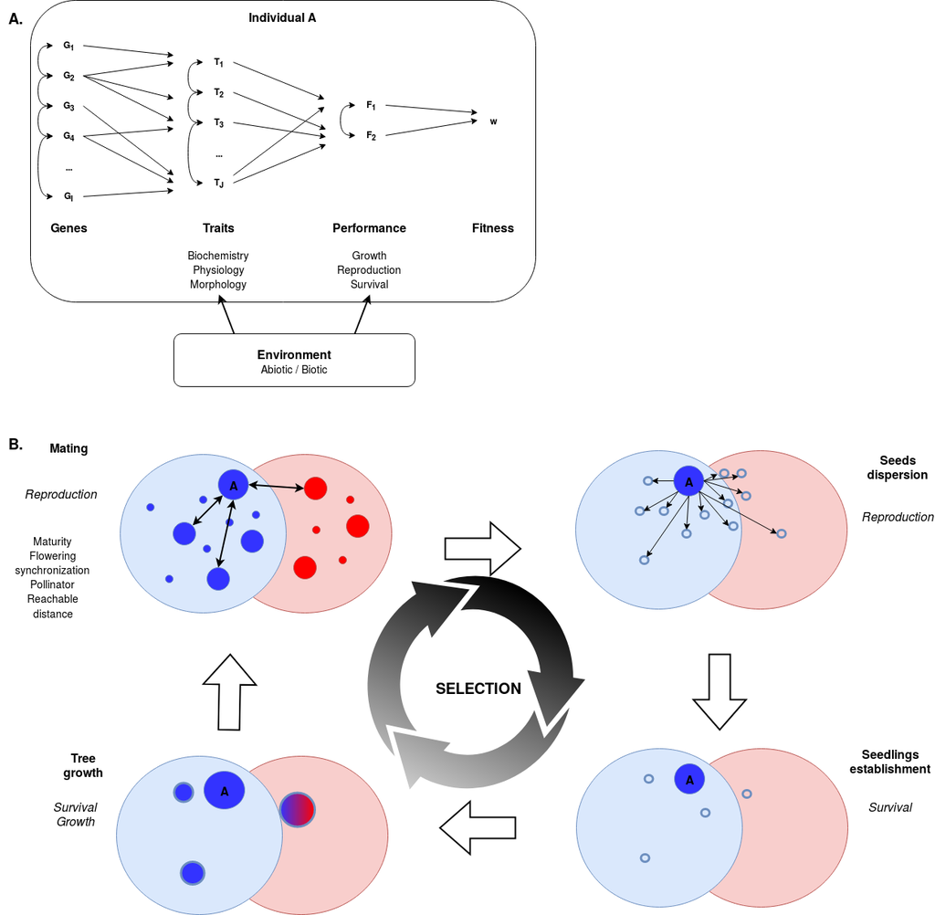

Figure 1: Model of individual functionement in interaction with its population and environment through time. *See model description paragraphs for more explanation.*

## Genes

- Genetic local adaptation arise from new mutations, standing genetic variation and adaptive introgression (Tigano & Friesen 2016).
- Genome to transcriptome and traits ? Effect of ontogeny ? Effect of envrionment ?
- Transcripts will result in molecules forming biochemistrial traits of the individual.

## Traits

- Traits variability will be shaped by: (i) genetic heritage, (ii) environment, (ii) ontogeny and (iv) random
- Basic functional traits resulting from transcript expression can be considered as primary traits. Interactions in individuals biochemistrial traits will then be the basis for individual physiological and morphological traits.
- Tropical tree genetic diversity (Scotti *et al.* 2016) in combination to the environement results in phenotypic variability (Albert 2015) and ultimately to *in situ* performance differences (Bec *et al.* 2015).

## Environment

- Local environment is both abiotic (nutrients, water, light…) and biotic (competition, predation)
- *On which level(s) is interacting the environment ?*

## Mating

- A first pre-zygotic barrier happens with all limits to individuals mating: (i) individuals maturity, (ii) flowering synchronization between individuals, (iii) common pollinator if needed, and (iv) distance reachability.
- Mating can happen between individuals of close but different species (Cannon & Lerdau 2015) resulting in the mating between the two genotypes in figure 1B.
- Tropical tree have great size, long life time, numerous seeds, large effective population size (Brown *et al.* 2004), outcrossing mating system and and maintain a strong gene flow (Hamrick *et al.* 1992; Nybom 2004). Thus, neutral processes maintain tree diversity over time by connecting populations with high gene flow and large effective population, while adaptive processes lead to local adaptation on short times with an expected genetic differentiation at the loci underlying heritable traits (Le Corre & Kremer 2003; Howe *et al.* 2003).

## Seeds dispersion and establishment

- Seeds dispersal and establishment are related to individual reproduction and survival performance capacities.
- Seeds establishment will be limited by abiotic environment through environmental filtering, but we can imagine an hybrid due to mating with the second ecotype to established in the second ecotype thanks to genetic introgression.
- Seeds establishment will be limited by biotic environment through the Jansen-Conell hypothesis.

## Conclusion: Performance & Selection

- Interaction between Performance (Ecology) and Selection (Evolution) through fitness
- Directional and balanced selection ?
- Selection is driving speciation.
- Before true phylogenetic species can be defined, populations can diverge into ecotypes due to local adaptation. At this stage of ecotypes, gene flow maintains adaptive polymorphisms inside the whole population (Tigano & Friesen 2016).
- When populations face a reproductive barrier, they will still largely share genetic variation due to the often large effective population size of the common ancestor, and potentially, due to hybridization between the incipient species. These incipient species can thus be qualified as species complex. At this stage of species complex, gene flow between incipient species can increase standing genetic variation favouring divergent selection, resulting in differential niche adaptation (Tigano & Friesen 2016).
- True phylogenetic species will exists where gene flow can still be responsible of adaptive introgression through hybrids in secondary contact, allowing species to share genetic polymorphisms or adaptations (Lindtke *et al.* 2013).

# Litterature review

*Litterature review is only here as a work in progress and will be integrated to the previous text structure.*

## TO CLASSIFY

- “The concept of dynamic species pools is underappreciated in community assembly.” (Mittelbach & Schemske 2015)
- “Community mean height, leaf area, and SLA increased in response to fertilization, and these shifts were driven almost entirely by intraspecific variation.” (Siefert & Ritchie 2016)
- “Trait shifts due to species turnover were generally weak and opposed intraspecific responses.” (Siefert & Ritchie 2016)
- “These results highlight the importance of intraspecific variation for short-term community functional responses” (Siefert & Ritchie 2016)
- “However, when intraspecific variation is heritable, allowing for the possibility of trait evolution, communities are much more resilient against environmental disturbance and exhibit far more predictable trait patterns.” (Barabás & D’Andrea 2016)

## Advocate for individual level

- “a much needed demonstration of the pivotal role of intraspecific variability in ecology” (Chave 2004)
- “Site and individual variability are typically ignored when considering crown size and light interception by trees, and residual variability is relegated to a residual error term, which is then ignored when studying ecological processes.” (Vieilledent *et al.* 2010)
- “Because interactions with the biotic and abiotic environment are ultimately based at the level of the individual, it makes sense to build a theory of community ecology starting with individuals.” (Violle *et al.* 2012)

## Observation

- “individual variability accounted for a large part of the variation in allometric relations” (Vieilledent *et al.* 2010)

## Phenotypic plasticity

- “The phenotypic plasticity of species in response to light and space availability suggests that intraspecific variability can have potential consequences on light interception and community dynamics.” (Vieilledent *et al.* 2010)

## References

Albert, C.H. (2015). Intraspecific trait variability matters. **26**, 7–8. Retrieved from http://doi.wiley.com/10.1111/jvs.12240

Albert, C.H., Grassein, F., Schurr, F.M., Vieilledent, G. & Violle, C. (2011). When and how should intraspecific variability be considered in trait-based plant ecology? **13**, 217–225. Retrieved from http://www.sciencedirect.com/science/article/pii/S143383191100028X http://linkinghub.elsevier.com/retrieve/pii/S143383191100028X

Albert, C.H., Thuiller, W., Yoccoz, N.G., Soudant, A., Boucher, F., Saccone, P. & Lavorel, S. (2010). Intraspecific functional variability: Extent, structure and sources of variation. *Journal of Ecology*, **98**, 604–613. Retrieved from http://doi.wiley.com/10.1111/j.1365-2745.2010.01651.x

Barabás, G. & D’Andrea, R. (2016). The effect of intraspecific variation and heritability on community pattern and robustness (D. Vasseur, Ed.). **19**, 977–986. Retrieved from http://doi.wiley.com/10.1111/ele.12636

Bec, J.L., Courbaud, B., Moguédec, G.L. & Pélissier, R. (2015). Characterizing tropical tree species growth strategies: Learning from inter-individual variability and scale invariance (M. Hanewinkel, Ed.). *PLoS ONE*, **10**, e0117028. Retrieved from http://dx.plos.org/10.1371/journal.pone.0117028

Brown, J.H., Gillooly, J.F., Allen, A.P., Savage, V.M. & West, G.B. (2004). Toward a metabolic theory of ecology. *Ecology*, pp. 1771–1789. Ecological Society of America. Retrieved from http://doi.wiley.com/10.1890/03-9000

Cannon, C.H. & Lerdau, M. (2015). Variable mating behaviors and the maintenance of tropical biodiversity. *Frontiers in Genetics*, **6**, 183. Retrieved from http://www.ncbi.nlm.nih.gov/pubmed/26042148 http://www.pubmedcentral.nih.gov/articlerender.fcgi?artid=PMC4437050

Cardinale, B.J., Duffy, J.E., Gonzalez, A., Hooper, D.U., Perrings, C., Venail, P., Narwani, A., Mace, G.M., Tilman, D., Wardle, D.A., Kinzig, A.P., Daily, G.C., Loreau, M., Grace, J.B., Larigauderie, A., Srivastava, D.S. & Naeem, S. (2012). Biodiversity loss and its impact on humanity. *Nature*, **486**, 59–67. Retrieved from http://www.nature.com/doifinder/10.1038/nature11148

Chave, J. (2004). Neutral theory and community ecology. *Ecology Letters*, **7**, 241–253. Retrieved from http://onlinelibrary.wiley.com/doi/10.1111/j.1461-0248.2003.00566.x/abstract

Chesson, P. (2000). Mechanisms of Maintenance of Species Diversity. *Annual Review of Ecology and Systematics*, **31**, 343–366. Retrieved from http://www.annualreviews.org/doi/10.1146/annurev.ecolsys.31.1.343

Clark, J.S. (2010). Individuals and the Variation Needed for High Species Diversity in Forest Trees. *Science*, **327**, 1129–1132. Retrieved from http://science.sciencemag.org/content/327/5969/1129 http://www.sciencemag.org/cgi/doi/10.1126/science.1183506

Clark, J.S., Dietze, M., Chakraborty, S., Agarwal, P.K., Ibanez, I., LaDeau, S. & Wolosin, M. (2007). Resolving the biodiversity paradox. *Ecology Letters*, **10**, 647–659.

Connell, J.H. (1978). Diversity in tropical rain forests and coral reefs. *Science*, **199**, 1302–1310. Retrieved from http://www.colby.edu/reload/biology/BI358j/Readings/Diversity in rainforests and coral reefs.pdf

De Queiroz, K. (2007). Species concepts and species delimitation. *Systematic Biology*, **56**, 879–886. Retrieved from http://academic.oup.com/sysbio/article/56/6/879/1653163/Species-Concepts-and-Species-Delimitation

Díaz, S., Fargione, J., Chapin III, F.S. & Tilman, D. (2006). Biodiversity {Loss} {Threatens} {Human} {Well}-{Being}. *PLoS Biol*, **4**, e277. Retrieved from http://dx.doi.org/10.1371/journal.pbio.0040277

Hamrick, J.L., Godt, M.J.W. & Sherman-Broyles, S.L. (1992). Factors influencing levels of genetic diversity in woody plant species. *New Forests*, **6**, 95–124. Retrieved from http://link.springer.com/10.1007/BF00120641

Howe, G.T., Aitken, S.N., Neale, D.B., Jermstad, K.D., Wheeler, N.C. & Chen, T.H. (2003). From genotype to phenotype: unraveling the complexities of cold adaptation in forest trees. *Canadian Journal of Botany*, **81**, 1247–1266. Retrieved from http://www.nrcresearchpress.com/doi/10.1139/b03-141

Hubbell, S.P. (2001). *The unified neutral theory of biodervisity*.

Laughlin, D.C., Joshi, C., Bodegom, P.M. van, Bastow, Z.A. & Fulé, P.Z. (2012). A predictive model of community assembly that incorporates intraspecific trait variation (T. Fukami, Ed.). *Ecology Letters*, **15**, 1291–1299. Retrieved from http://doi.wiley.com/10.1111/j.1461-0248.2012.01852.x

Le Corre, V. & Kremer, A. (2003). Genetic variability at neutral markers, quantitative trait loci and trait in a subdivided population under selection. *Genetics*, **164**, 1205–1219. Retrieved from http://www.genetics.org/content/164/3/1205.short

Liang, J., Crowther, T.W., Picard, N., Wiser, S., Zhou, M., Alberti, G., Schulze, E.-D., McGuire, D., Bozzato, F., Pretzsch, H., De-Miguel, S., Paquette, A., Hérault, B., Scherer-Lorenzen, M., Barrett, C.B., Glick, H.B., Hengeveld, G.M., Nabuurs, G.-J., Pfautsch, S., Viana, H., Vibrans, A.C., Ammer, C., Schall, P., Verbyla, D., Tchebakova, N., Fischer, M., Watson, J.V., Chen, H.Y., Lei, X., Schelhaas, M.-J., Lu, H., Gianelle, D., Parfenova, E.I., Salas, C., Lee, E., Lee, B., Kim, H.S., Bruelheide, H., Coomes, D.A., Piotto, D., Sunderland, T., Schmid, B., Gourlet-Fleury, S., Sonké, B., Tavani, R., Zhu, J., Brandl, S., Vayreda, J., Kitahara, F., Searle, E.B., Neldner, V.J., Ngugi, M.R., Baraloto, C., Frizzera, L., Bałazy, R., Oleksyn, J., Zawiła-Niedźwiecki, T., Bouriaud, O., Bussotti, F., Finér, L., Jaroszewicz, B., Jucker, T., Valladares, F., Jagodzinski, A.M., Peri, P.L., Gonmadje, C., Marthy, W., O’Brien, T., Martin, E.H., Marshall, A., Rovero, F., Bitariho, R., Niklaus, P.A., Alvarez-Loayza, P., Chamuya, N., Valencia, R., Mortier, F., Wortel, V., Engone-Obiang, N.L., Ferreira, L.V., Odeke, D.E., Vasquez, R.M. & Reich, P.B. (2016). Positive biodiversity–productivity relationship predominant in global forests. *Science*, **354**, 196. Retrieved from http://science.sciencemag.org/content/354/6309/aaf8957

Lindtke, D., González-Martínez, S.C., Macaya-Sanz, D. & Lexer, C. (2013). Admixture mapping of quantitative traits in Populus hybrid zones: power and limitations. *Heredity*, **111**, 474–485. Retrieved from http://www.nature.com/doifinder/10.1038/hdy.2013.69

Loreau, M. (2000). Biodiversity and ecosystem functioning: recent theoretical advances. *Oikos*, **91**, 3–17. Retrieved from http://onlinelibrary.wiley.com/doi/10.1034/j.1600-0706.2000.910101.x/full

Lortie, C.J., Brooker, R.W., Choler, P.P., Kikvidze, Z., Michalet, R., Pugnaire, F.I. & Callaway, R.M. (2004). Rethinking plant community theory. *Oikos*, **107**, 433–438. Retrieved from http://onlinelibrary.wiley.com/doi/10.1111/j.0030-1299.2004.13250.x/full http://doi.wiley.com/10.1111/j.0030-1299.2004.13250.x

Mayden, R.L. (1997). A hierarchy of species concepts: the denouement in the saga of the species problem. *Species. The units of biodiversity.*, 381–423. Retrieved from https://philpapers.org/rec/MAYAHO-6

Mayr, E. (1996). What Is a Species, and What Is Not? *Philosophy of Science*, **63**, 262. Retrieved from http://www.journals.uchicago.edu/doi/10.1086/289912

Messier, J., McGill, B.J. & Lechowicz, M.J. (2010). How do traits vary across ecological scales? A case for trait-based ecology. *Ecology Letters*, **13**, 838–848. Retrieved from https://www.researchgate.net/profile/Julie{\_}Messier/publication/267334723{\_}Messier{\_}et{\_}al{\_}2010{\_}How{\_}do{\_}traits{\_}vary{\_}across{\_}ecological{\_}scales{\_}Ecology{\_}Letters/links/544cb4680cf24b5d6c40ae91/Messier-et-al-2010-How-do-traits-vary-across-ecological-scales-Ecology-L

Mittelbach, G.G. & Schemske, D.W. (2015). Ecological and evolutionary perspectives on community assembly (K. Suding, Ed.). **30**, 241–247. Retrieved from http://doi.wiley.com/10.1111/ele.12760

Naeem, S., Loreau, M. & Inchausti, P. (2002). Biodiversity and ecosystem functioning : the emergence of a synthetic ecological framework. *Biodiversity and ecosystem functioning: synthesis and perspectives*, 3–11. Retrieved from http://www.abe.com.pl/html/samples/b/0198515715.pdf

Nybom, H. (2004). Comparison of different nuclear DNA markers for estimating intraspecific genetic diversity in plants. *Molecular Ecology*, **13**, 1143–1155. Retrieved from http://doi.wiley.com/10.1111/j.1365-294X.2004.02141.x

Oliver, T.H., Heard, M.S., Isaac, N.J., Roy, D.B., Procter, D., Eigenbrod, F., Freckleton, R., Hector, A., Orme, C.D.L., Petchey, O.L., Proença, V., Raffaelli, D., Suttle, K.B., Mace, G.M., Martín-López, B., Woodcock, B.A. & Bullock, J.M. (2015). Biodiversity and Resilience of Ecosystem Functions. *Trends in Ecology and Evolution*, **30**, 673–684. Retrieved from http://linkinghub.elsevier.com/retrieve/pii/S0169534715002189

Scotti, I., González-Martínez, S.C., Budde, K.B. & Lalagüe, H. (2016). Fifty years of genetic studies: what to make of the large amounts of variation found within populations? *Annals of Forest Science*, **73**, 69–75.

Siefert, A. & Ritchie, M.E. (2016). Intraspecific trait variation drives functional responses of old-field plant communities to nutrient enrichment. *Oecologia*, **181**, 245–255. Retrieved from http://link.springer.com/10.1007/s00442-016-3563-z

Tigano, A. & Friesen, V.L. (2016). Genomics of local adaptation with gene flow. *Molecular Ecology*, **25**, 2144–2164.

Vieilledent, G., Courbaud, B., Kunstler, G., Dhôte, J.F. & Clark, J.S. (2010). Individual variability in tree allometry determines light resource allocation in forest ecosystems: A hierarchical Bayesian approach. *Oecologia*, **163**, 759–773. Retrieved from http://link.springer.com/10.1007/s00442-010-1581-9

Violle, C., Enquist, B.J., McGill, B.J., Jiang, L., Albert, C.H., Hulshof, C., Jung, V. & Messier, J. (2012). The return of the variance: Intraspecific variability in community ecology. *Trends in Ecology and Evolution*, **27**, 244–252. Retrieved from http://linkinghub.elsevier.com/retrieve/pii/S0169534711003375

Weiher, E. & Keddy, P.A. (1995). Assembly Rules, Null Models, and Trait Dispersion: New Questions from Old Patterns. *Oikos*, **74**, 159. Retrieved from http://www.jstor.org/stable/3545686 http://www.jstor.org/stable/3545686?origin=crossref

Wright, J.S. (2002). Plant diversity in tropical forests: a review of mechanisms of species coexistence. *Oecologia*, **130**, 1–14.

Yachi, S. & Loreau, M. (1999). Biodiversity and ecosystem productivity in a fluctuating environment: The insurance hypothesis. *Proceedings of the National Academy of Sciences*, **96**, 1463–1468. Retrieved from http://www.ncbi.nlm.nih.gov/pubmed/9990046 http://www.pubmedcentral.nih.gov/articlerender.fcgi?artid=PMC15485 http://www.pnas.org/cgi/doi/10.1073/pnas.96.4.1463